# JHPractical ML Week 4 Assignment

Sinead O’Donovan

January 31, 2016

# Project Description

The goal of your project is to predict the manner in which they did the exercise.This is the “classe” variable in the training set. You may use any of the other variables to predict with. You should create a report describing how you built your model, how you used cross validation, what you think the expected out of sample error is, and why you made the choices you did. You will also use your prediction model to predict 20 different test cases.In this project, your goal will be to use data from accelerometers on the belt, forearm, arm, and dumbell of 6 participants. They were asked to perform barbell lifts correctly and incorrectly in 5 different ways.

## Prep Environment

The first thing I did was install and load the libraries I will be using

```r
library(caret)
library(ISLR)
```

```r
library(ggplot2)
```

## Loading Data

I next read in the data and also took a look at what the data looks like

```r
rawdata <- read.csv("pml-training.csv",na.strings=c("NA","","#DIV/0!"), header = TRUE)
validation <-read.csv("pml-testing.csv",na.strings=c("NA","","#DIV/0!"), header = TRUE)
```

## Inspect Data

I inspected the data to see how much data prep we need to do, I did change the read.csv to account for the different type of NAs. Once I understood the data I commented this out after I ran it but kept the code so I could use it later if needed

```r
## str(rawdata$classe)
##str(rawdata)
## dim(rawdata)
## dim(validation)
## summary(validation)
##names(validation)
```

## Data Cleansing

```r
rawdata <-rawdata[,-seq(1:7)]
validation <- validation[,-seq(1:7)]
indexNA <- as.vector(sapply(rawdata[,1:152],function(x) {length(which(is.na(x)))!=0}))
rawdata <- rawdata[,!indexNA]
validation <- validation[,!indexNA]
```

## Creating Data Sets

I split the data into training and testing data sets. I decided the raw data that I loaded with only 20 values could be a cross validation set.

```r
set.seed(1234)
inTrain = createDataPartition(rawdata$classe, p=0.7, list=FALSE)
training = rawdata[inTrain,]
testing = rawdata[-inTrain,]
```

## Modeling

I than did different model training and prediction first I took a look at boosting to see how its accuracy was. It was .97 approximately.

```r
set.seed(1234)
modgbm <-train(classe ~.,method="gbm",data=training,verbose = F, trControl = trainControl(method = "cv", number=10))
```

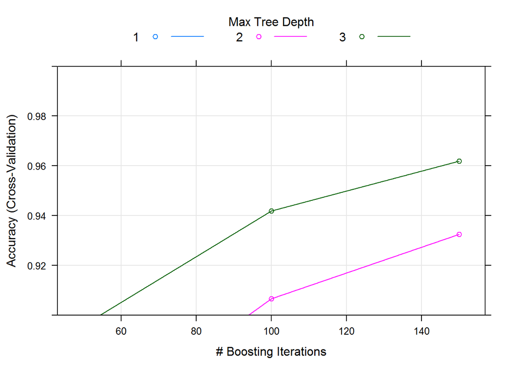

```r
### plot the accuracy of the test set
```

```r
predgbm <-predict(modgbm, testing)
### calculate the error rates and accuracies
sum(predgbm == testing$classe) / length(predgbm)
```

```
## [1] 0.9656754
```

```r
confusionMatrix(testing$classe, predgbm)$table
```

```
##           Reference
## Prediction    A    B    C    D    E
##          A 1654   12    4    2    2
##          B   38 1076   21    4    0
##          C    0   26  984   13    3
##          D    0    5   25  927    7
##          E    1    8   15   16 1042
```

next I took a look at Random Forest

```r
### training the models using random forest
set.seed(1234)
modrf <-train(classe ~.,method="rf",data=training,importance=T, trControl=trainControl(method="cv"),number=10)
predrf <-predict(modrf, testing)
confusionMatrix(testing$classe, predrf)$table
```

```
##           Reference
## Prediction    A    B    C    D    E
##          A 1674    0    0    0    0
##          B   12 1126    1    0    0
##          C    0    5 1017    4    0
##          D    0    3    6  953    2
##          E    0    1    3    3 1075
```

Lets plot accuracy

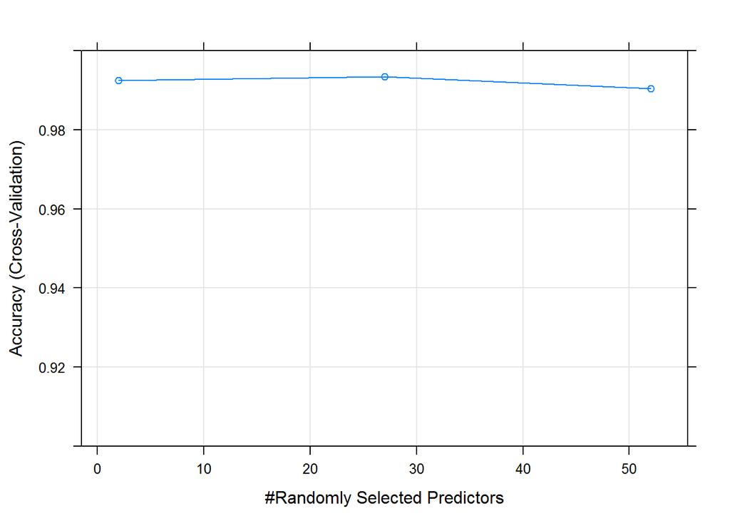

Calculate the accuracy of the two models to decide best one

```r
## Calculate accuracy
accrf<-sum(predrf == testing$classe)/length(predrf)
accgbm<-sum(predgbm == testing$classe)/length(predgbm)
print(accrf)
```

```
## [1] 0.9932031
```

```r
print(accgbm)
```

```
## [1] 0.9656754
```

You can see that random forest is more accurate.

## Final Conclusions

Because the accuracy rates are higher Random Forest it is the best model so ran this against the validation data to predict the final results

```r
## final predictions for the validation data
predrfv <-predict(modrf, validation)
predrfv
```

```
##  [1] B A B A A E D B A A B C B A E E A B B B
## Levels: A B C D E
```

The final predictions for the validation set and quiz are B A B A A E D B A A B C B A E E A B B B, ## Levels: A B C D E